# Practico 12

# Introducción

Información rápida sobre las operaciones clásicas de estas librerías se encuentran en las llamadas **cheatsheets**. A continuación una lista con las mismas.

- [Cheatsheet de readr](https://evoldyn.gitlab.io/evomics-2018/ref-sheets/R_data-import.pdf)
- [Cheatsheet de dplyr + tidyr](https://rstudio.com/wp-content/uploads/2015/02/data-wrangling-cheatsheet.pdf)
- [Cheatsheet de ggplot2](https://rstudio.com/wp-content/uploads/2015/03/ggplot2-cheatsheet.pdf)

# Demostración

## Leyendo datos con la librería **readr**

```r
# cargo las librerias que utilizamos en el practico
library(magrittr)
library(tidyverse)

# cargo la tabla CSV
aeropuertos = readr::read_csv('airport-codes.csv')
# la visualizo
aeropuertos
```

```
## # A tibble: 55,907 x 12
##    ident type  name  elevation_ft continent iso_country iso_region municipality
##    <chr> <chr> <chr>        <dbl> <chr>     <chr>       <chr>      <chr>
##  1 00A   heli… Tota…           11 <NA>      US          US-PA      Bensalem
##  2 00AA  smal… Aero…         3435 <NA>      US          US-KS      Leoti
##  3 00AK  smal… Lowe…          450 <NA>      US          US-AK      Anchor Point
##  4 00AL  smal… Epps…          820 <NA>      US          US-AL      Harvest
##  5 00AR  clos… Newp…          237 <NA>      US          US-AR      Newport
##  6 00AS  smal… Fult…         1100 <NA>      US          US-OK      Alex
##  7 00AZ  smal… Cord…         3810 <NA>      US          US-AZ      Cordes
##  8 00CA  smal… Gold…         3038 <NA>      US          US-CA      Barstow
##  9 00CL  smal… Will…           87 <NA>      US          US-CA      Biggs
## 10 00CN  heli… Kitc…         3350 <NA>      US          US-CA      Pine Valley
## # … with 55,897 more rows, and 4 more variables: gps_code <chr>,
## #   iata_code <chr>, local_code <chr>, coordinates <chr>
```

## Realizando modificaciones con la librería **tidyr**

```r
# realizo una modificacion con la libreria tidyr
aeropuertos %<>% tidyr::separate(data = ., col = 'coordinates', into = c('lon', 'lat'), sep = ', ')
aeropuertos$lat %<>% as.numeric()
aeropuertos$lon %<>% as.numeric()

# viasualizo el resultado
aeropuertos
```

```
## # A tibble: 55,907 x 13
##    ident type  name  elevation_ft continent iso_country iso_region municipality
##    <chr> <chr> <chr>        <dbl> <chr>     <chr>       <chr>      <chr>
##  1 00A   heli… Tota…           11 <NA>      US          US-PA      Bensalem
##  2 00AA  smal… Aero…         3435 <NA>      US          US-KS      Leoti
##  3 00AK  smal… Lowe…          450 <NA>      US          US-AK      Anchor Point
##  4 00AL  smal… Epps…          820 <NA>      US          US-AL      Harvest
##  5 00AR  clos… Newp…          237 <NA>      US          US-AR      Newport
##  6 00AS  smal… Fult…         1100 <NA>      US          US-OK      Alex
##  7 00AZ  smal… Cord…         3810 <NA>      US          US-AZ      Cordes
##  8 00CA  smal… Gold…         3038 <NA>      US          US-CA      Barstow
##  9 00CL  smal… Will…           87 <NA>      US          US-CA      Biggs
## 10 00CN  heli… Kitc…         3350 <NA>      US          US-CA      Pine Valley
## # … with 55,897 more rows, and 5 more variables: gps_code <chr>,
## #   iata_code <chr>, local_code <chr>, lon <dbl>, lat <dbl>
```

```r
# visualizamos un caso en el cual existen NAs en nuestra tabla.
aeropuertos %>%
  filter(is.na(iso_country))
```

```
## # A tibble: 246 x 13
##    ident type  name  elevation_ft continent iso_country iso_region municipality
##    <chr> <chr> <chr>        <dbl> <chr>     <chr>       <chr>      <chr>
##  1 FYAA  smal… Ai-A…         2000 AF        <NA>        NA-KU      Ai-Ais
##  2 FYAB  smal… Aroa…         3235 AF        <NA>        NA-KA      Aroab
##  3 FYAK  smal… Auss…          970 AF        <NA>        NA-KA      Aussenkehr
##  4 FYAM  smal… Amin…         4012 AF        <NA>        NA-OH      Aminuis
##  5 FYAR  medi… Aran…         1905 AF        <NA>        NA-ER      Arandis
##  6 FYAS  smal… Aus …         4856 AF        <NA>        NA-KA      Aus
##  7 FYAV  smal… Aria…         2549 AF        <NA>        NA-KA      Ariamsvley
##  8 FYBC  smal… Beth…         3260 AF        <NA>        NA-KA      Bethanien
##  9 FYBJ  smal… Bitt…         4167 AF        <NA>        NA-HA      Bitterwasser
## 10 FYEK  smal… Epuk…         4892 AF        <NA>        NA-OH      Epukiro
## # … with 236 more rows, and 5 more variables: gps_code <chr>, iata_code <chr>,
## #   local_code <chr>, lon <dbl>, lat <dbl>
```

```r
aeropuertos %>%
 left_join(x = ., y = pais_vs_continente.final, by = c('iso_country' = 'codigo_pais')) %>%
 dplyr::select(-continent) -> aeropuertos
### aeropuertos %<>% dplyr::rename(continente = 'continent')
###
### aeropuertos %<>% filter(!is.na(ident) & !is.na(type) & !is.na(elevation_ft) & !is.na(continente) & !is.na(iso_country) & !is.na(iso_region) & ### !is.na(municipality) & !is.na(gps_code) & !is.na(iata_code))

aeropuertos
```

```
## # A tibble: 57,323 x 13
##    ident type  name  elevation_ft iso_country iso_region municipality gps_code
##    <chr> <chr> <chr>        <dbl> <chr>       <chr>      <chr>        <chr>
##  1 00A   heli… Tota…           11 US          US-PA      Bensalem     00A
##  2 00AA  smal… Aero…         3435 US          US-KS      Leoti        00AA
##  3 00AK  smal… Lowe…          450 US          US-AK      Anchor Point 00AK
##  4 00AL  smal… Epps…          820 US          US-AL      Harvest      00AL
##  5 00AR  clos… Newp…          237 US          US-AR      Newport      <NA>
##  6 00AS  smal… Fult…         1100 US          US-OK      Alex         00AS
##  7 00AZ  smal… Cord…         3810 US          US-AZ      Cordes       00AZ
##  8 00CA  smal… Gold…         3038 US          US-CA      Barstow      00CA
##  9 00CL  smal… Will…           87 US          US-CA      Biggs        00CL
## 10 00CN  heli… Kitc…         3350 US          US-CA      Pine Valley  00CN
## # … with 57,313 more rows, and 5 more variables: iata_code <chr>,
## #   local_code <chr>, lon <dbl>, lat <dbl>, continente <chr>
```

## Obteniendo algunos valores descriptivos con funciones de la librería **dplyr**

Ahora que contamos con nuestra tabla completa, podemos obtener algunos valores descriptivos valiéndonos de las funciones **group_by()** y **summarise()**

Podríamos, por ejemplo, preguntarnos cuántos aeropuertos tenemos descritos por continente. Al realizar estas operaciones es necesario ser cuidadosos, ya que filas repetidas pueden distorsionar el estudio de las variables de interés.

```r
aeropuertos %>%
  dplyr::select(name, continente) %>%
  unique() %>%
  group_by(continente) %>%
  summarise(numero_aeropuertos = n())
```

```
## # A tibble: 8 x 2
##   continente    numero_aeropuertos
##   <chr>                      <int>
## 1 Africa                      3348
## 2 Antarctica                    31
## 3 Asia                        6046
## 4 Europe                      8582
## 5 North America              26344
## 6 Oceania                     3016
## 7 South America               7254
## 8 <NA>                           6
```

```r
aeropuertos %>%
  dplyr::select(name, continente, type) %>%
  unique() %>%
  group_by(continente, type) %>%
  summarise(numero_aeropuertos = n())
```

```
## # A tibble: 45 x 3
## # Groups:   continente [8]
##    continente type           numero_aeropuertos
##    <chr>      <chr>                       <int>
##  1 Africa     closed                         75
##  2 Africa     heliport                       10
##  3 Africa     large_airport                  48
##  4 Africa     medium_airport                447
##  5 Africa     seaplane_base                   1
##  6 Africa     small_airport                2773
##  7 Antarctica closed                          2
##  8 Antarctica medium_airport                  4
##  9 Antarctica small_airport                  25
## 10 Asia       closed                        403
## # … with 35 more rows
```

```r
aeropuertos %>%
  filter(!is.na(elevation_ft)) %>%
  dplyr::select(name, continente, iso_country, elevation_ft) %>%
  unique() %>%
  group_by(continente) %>%
  summarise(numero_aeropuertos = mean(elevation_ft))
```

```
## # A tibble: 8 x 2
##   continente    numero_aeropuertos
##   <chr>                      <dbl>
## 1 Africa                     2578.
## 2 Antarctica                 1069.
## 3 Asia                       1210.
## 4 Europe                      785.
## 5 North America              1209.
## 6 Oceania                     904.
## 7 South America              1317.
## 8 <NA>                       1841
```

## Visualizando con la librería **ggplot2**

Visualizaremos ahora nuestro set de datos. Empezaremos graficando, tomando la variable **lon** como coordenada *x* de nuestro gráfico y la variable **lat** como coordenada *y*, especificando estos argumentos con la función **aes()** de la librería.

A su vez, debemos elegir una geometría que represente a nuestros puntos. En este caso, llamaremos a la función **geom_point()** para especificar que la misma será la geometría de puntos.

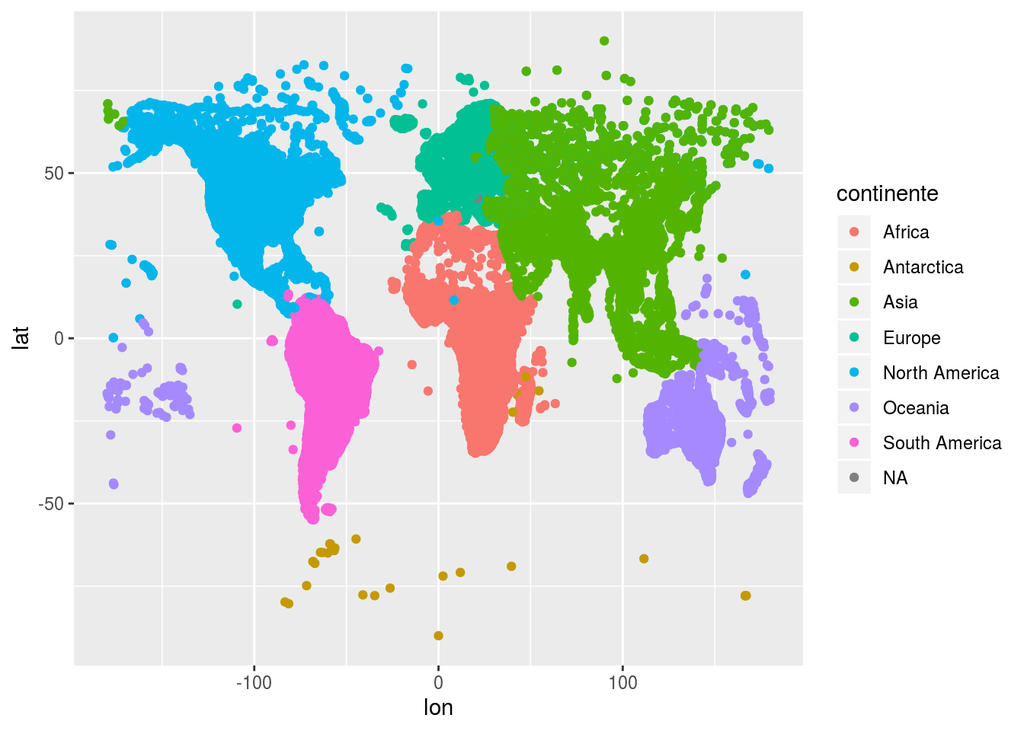

```r
aeropuertos %>%
#  dplyr::filter(., continente == 'South America') %>%
  ggplot(data = .,
         mapping = aes(x = lon, y = lat, color = continente)) +
  geom_point()
```

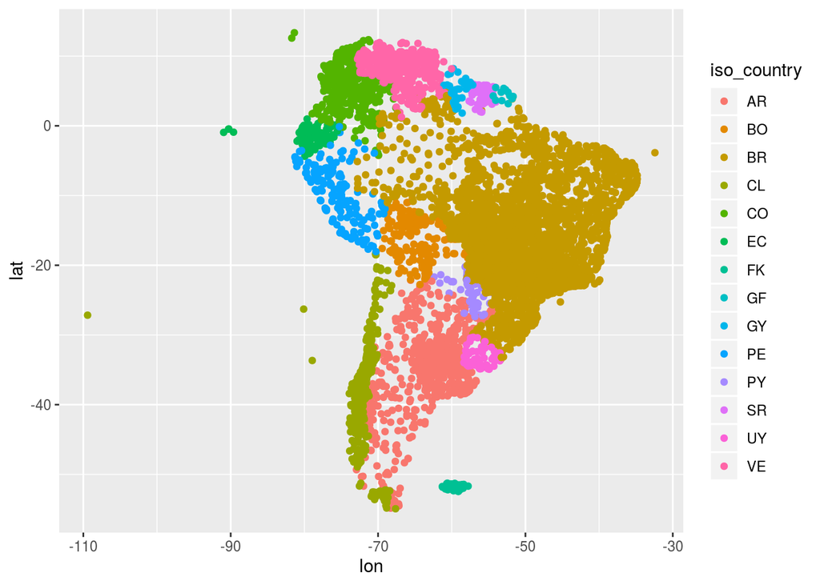

```r
aeropuertos %>%
  dplyr::filter(., continente == 'South America') %>%
  ggplot(data = .,
         mapping = aes(x = lon, y = lat, color = iso_country)) +
  geom_point()
```

A su vez podriamos realizar un boxplot para visualizar la dispersión que posee cada continente en torno a esta variable. Para ello podemos utilizar la función **geom_boxplot()** para visualizar nuestras variables con esa geometría.

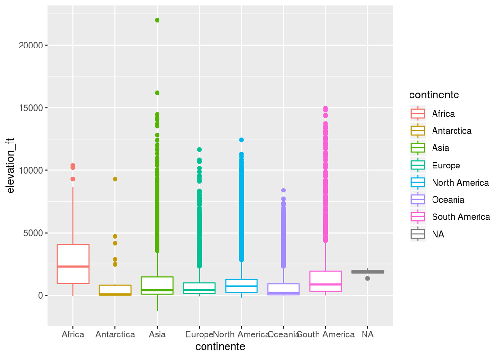

```r
aeropuertos %>%
  ggplot(data = .,
         mapping = aes(x = continente, y = elevation_ft, color = continente)) +
  geom_boxplot()
```

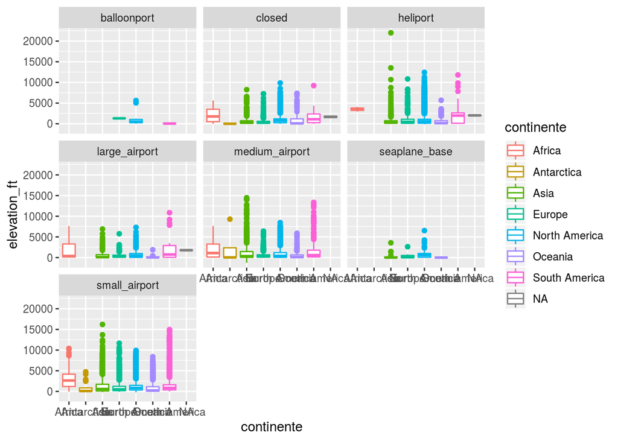

```r
aeropuertos %>%
  ggplot(data = .,
         mapping = aes(x = continente, y = elevation_ft, color = continente)) +
  geom_boxplot() +
  facet_wrap(~type)
```

# Un poco más de información

[figure not shown]

> En la mayoría de los casos los datos con los que se trabaja suelen ser importados de archivos alojados en disco duro.

> Las funciones alojadas en esta librería comienzan todas con el prefijo **read_***, acompañadas del formato de texto que son capaces de leer. Así, por ejemplo, read_csv() es la función de esta librería diseñada para cargar archivos de texto con formato csv.

> En general estas funciones también poseen una sintaxis similar, por lo que al aprenderse a utilizar una ya se posee el conocimiento para lograr cargar otros formatos.

[figure not shown]

> La librería tidyverse fue construída para trabajar sobre conjuntos de datos que poseen un formato en particular: estos datos son llamados *tidy data*.

> Para que un set sea caracterizado como *tidy data* debe poseer tres características que están interrelacionadas:

> • Cada variable debe estar representada en una columna

> • Cada observación debe estar representada en una fila

> • Cada valor debe estar alojado en una celda

> Esto no siempre se cumple en la vida cotidiana. Los *datos crudos* con los que solemos presentarnos suelen tener uno (o los dos) siguientes defectos que nos > impiden definirlos como *tidy datasets*:

> • Una variable puede estar siendo representada en más de una columna

> • Una observación puede estar representada en más de una fila

> Estos problemas pueden ser resueltos con las funciones de la librería **tidyr**. Como su nombre indica, esta librería tiene como objetivo generar *tidy datasets* > en R.

> Sus funciones más importantes son

> • **pivot_longer()**: hace a un dataset más *largo*, alojando valores que antes se encontraban en columnas en filas.

> • **pivot_wider()**: lo opuesto de pibot_longer(). Un dataset se hace más *ancho* al aumentar el número de columnas y disminuir el número de filas.

> • **separate()**: separa observaciones de una columna en varias columnas, al separar los valores de sus celdas según un separador.

> • **unite()**: lo opuesto de separate(). Se unen observaciones de diferentes columnas, utilizando para ello un caracter especificado.

[figure not shown]

> Estas funciones son

> • **filter()**: filtra un *tibble* teniendo en cuenta condiciones lógicas que operan sobre sus columnas.

> • **arrange()**: ordena un *tibble* en base a los valores de una o más columnas

> • **select()**: selecciona/descarta columnas de un *tibble*.

> • **mutate()**: genera nuevas columnas en un *tibble* en base a operaciones ejecutadas sobre columnas preexistentes